# IODS course project

# Week 5 - Dimensionality reduction techniques

```r
# loading the data
human <- read.csv("http://s3.amazonaws.com/assets.datacamp.com/production/course_2218/datasets/human2.txt", header = TRUE)
dim(human)
```

```
## [1] 155   8
```

## Data overview

First, let’s have a look at the data. Decription of the data variables is available [here](https://raw.githubusercontent.com/TuomoNieminen/Helsinki-Open-Data-Science/master/datasets/human_meta.txt).

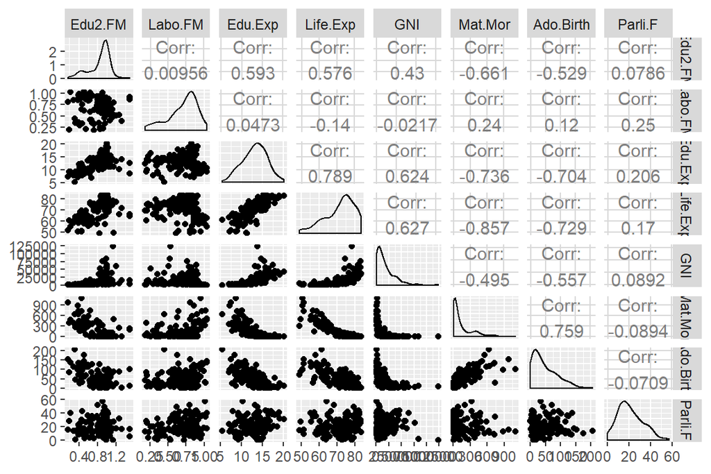

```r
library(corrplot)
library(GGally)
# visualize the 'human_' variables
ggpairs(human)
```

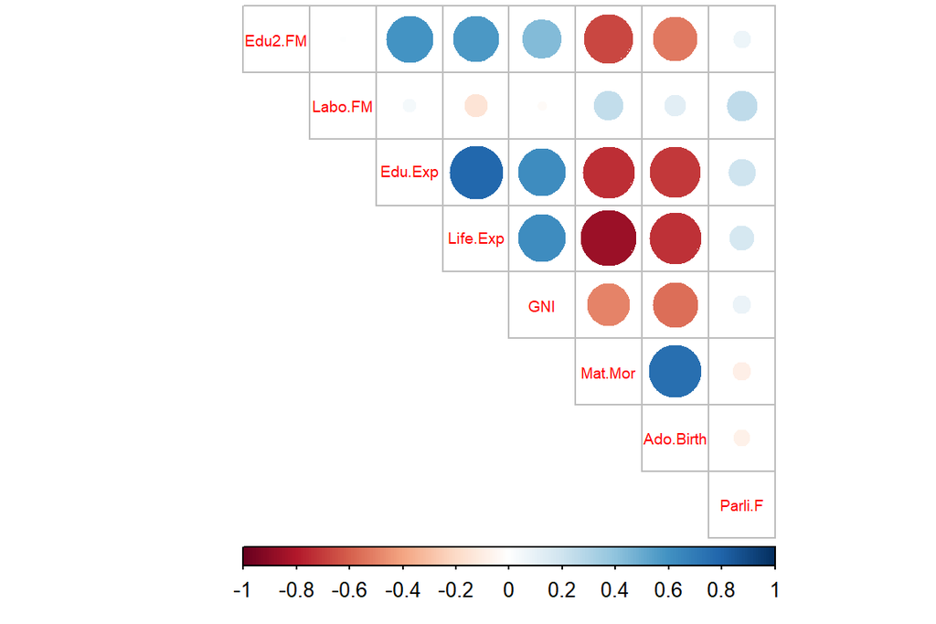

```r
# compute the correlation matrix and visualize it with corrplot
corrplot(cor(human), method="circle", type = "upper", cl.pos = "b", tl.pos = "d", tl.cex = 0.6)
```

```r
summary(human)
```

```
##     Edu2.FM          Labo.FM          Edu.Exp         Life.Exp
##  Min.   :0.1717   Min.   :0.1857   Min.   : 5.40   Min.   :49.00
##  1st Qu.:0.7264   1st Qu.:0.5984   1st Qu.:11.25   1st Qu.:66.30
##  Median :0.9375   Median :0.7535   Median :13.50   Median :74.20
##  Mean   :0.8529   Mean   :0.7074   Mean   :13.18   Mean   :71.65
##  3rd Qu.:0.9968   3rd Qu.:0.8535   3rd Qu.:15.20   3rd Qu.:77.25
##  Max.   :1.4967   Max.   :1.0380   Max.   :20.20   Max.   :83.50
##       GNI            Mat.Mor         Ado.Birth         Parli.F
##  Min.   :   581   Min.   :   1.0   Min.   :  0.60   Min.   : 0.00
##  1st Qu.:  4198   1st Qu.:  11.5   1st Qu.: 12.65   1st Qu.:12.40
##  Median : 12040   Median :  49.0   Median : 33.60   Median :19.30
##  Mean   : 17628   Mean   : 149.1   Mean   : 47.16   Mean   :20.91
##  3rd Qu.: 24512   3rd Qu.: 190.0   3rd Qu.: 71.95   3rd Qu.:27.95
##  Max.   :123124   Max.   :1100.0   Max.   :204.80   Max.   :57.50
```

The largest negative negative correlation (big dark red circle in corrplot) is between *Life.Exp* and *Mat.Mor* (-0.857). Also, there is strong negative correlation between: *Edu.Exp* and *Mat.Mor*, *Edu.Exp* and *Ado.Birth*, *Life.Exp* and *Ado.Birth*, and *Edu2Fm* and *Mat.Mor*. Strong positive correlation is between *Edu.Exp* and *Life.Exp* and *Mat.Mor* and *Ado.Birth*.

It is also important to notice that variable GNI has huge variance (min. 581, max. 123124), a lot bigger than other variables.

## Principal component analysis (PCA) on the not standardized human data

Now we will perform principal component analysis (PCA) on the not standardized human data.

```r
pca_human <- prcomp(human)
pca_human
```

```
## Standard deviations (1, .., p=8):
## [1] 1.854416e+04 1.855219e+02 2.518701e+01 1.145441e+01 3.766241e+00
## [6] 1.565912e+00 1.912052e-01 1.591112e-01
##
## Rotation (n x k) = (8 x 8):
##                     PC1           PC2           PC3           PC4
## Edu2.FM   -5.607472e-06  0.0006713951 -3.412027e-05 -2.736326e-04
## Labo.FM    2.331945e-07 -0.0002819357  5.302884e-04 -4.692578e-03
## Edu.Exp   -9.562910e-05  0.0075529759  1.427664e-02 -3.313505e-02
## Life.Exp  -2.815823e-04  0.0283150248  1.294971e-02 -6.752684e-02
## GNI       -9.999832e-01 -0.0057723054 -5.156742e-04  4.932889e-05
## Mat.Mor    5.655734e-03 -0.9916320120  1.260302e-01 -6.100534e-03
## Ado.Birth  1.233961e-03 -0.1255502723 -9.918113e-01  5.301595e-03
## Parli.F   -5.526460e-05  0.0032317269 -7.398331e-03 -9.971232e-01
##                     PC5           PC6           PC7           PC8
## Edu2.FM   -0.0022935252  2.180183e-02  6.998623e-01  7.139410e-01
## Labo.FM    0.0022190154  3.264423e-02  7.132267e-01 -7.001533e-01
## Edu.Exp    0.1431180282  9.882477e-01 -3.826887e-02  7.776451e-03
## Life.Exp   0.9865644425 -1.453515e-01  5.380452e-03  2.281723e-03
## GNI       -0.0001135863 -2.711698e-05 -8.075191e-07 -1.176762e-06
## Mat.Mor    0.0266373214  1.695203e-03  1.355518e-04  8.371934e-04
## Ado.Birth  0.0188618600  1.273198e-02 -8.641234e-05 -1.707885e-04
## Parli.F   -0.0716401914 -2.309896e-02 -2.642548e-03  2.680113e-03
```

There are 8 principal componenets.

```r
library(dplyr)
s <- summary(pca_human)
s
```

```
## Importance of components:
##                              PC1      PC2   PC3   PC4   PC5   PC6    PC7
## Standard deviation     1.854e+04 185.5219 25.19 11.45 3.766 1.566 0.1912
## Proportion of Variance 9.999e-01   0.0001  0.00  0.00 0.000 0.000 0.0000
## Cumulative Proportion  9.999e-01   1.0000  1.00  1.00 1.000 1.000 1.0000
##                           PC8
## Standard deviation     0.1591
## Proportion of Variance 0.0000
## Cumulative Proportion  1.0000
```

```r
# rounded percetanges of variance captured by each PC
pca_pr <- round(100*s$importance[2, ], digits = 1)

# print out the percentages of variance
pca_pr
```

```
## PC1 PC2 PC3 PC4 PC5 PC6 PC7 PC8
## 100   0   0   0   0   0   0   0
```

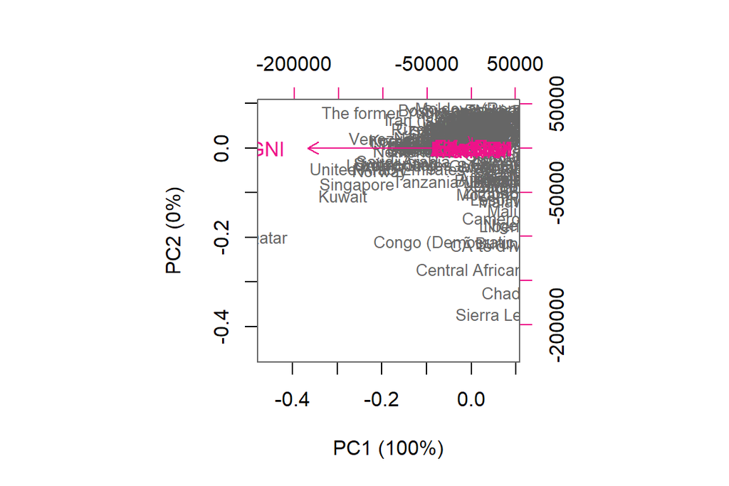

```r
# create object pc_lab to be used as axis labels
pc_lab <- paste0(names(pca_pr), " (", pca_pr, "%)")


# draw a biplot
biplot(pca_human, cex = c(0.8, 1), col = c("grey40", "deeppink2"), xlab = pc_lab[1], ylab = pc_lab[2])
```

When we round percetanges of variance captured by each PC, we get that the PC1 holds all the variance (PC1 is 100%). So, basicaly, we get just one dimension. Since the data is not standardized, PCA finds that variable *GNI*, which has the largest variance, is the most important. Everything else is grouped together, there are no angles between arrows (or arrows whatsoever). The *GNI* arrow is the longest, because of high standard deviation of GNI.

This graph doesn’t tell us anything about the data, execpt the fact that *GNI* has very large variance in comparison to other variables.

## PCA on the standardized human data

Now we will standardize data and then repeat the previous step.

```r
# standardize the variables
human_std <- scale(human)

# print out summaries of the standardized variables
summary(human_std)
```

```
##     Edu2.FM           Labo.FM           Edu.Exp           Life.Exp
##  Min.   :-2.8189   Min.   :-2.6247   Min.   :-2.7378   Min.   :-2.7188
##  1st Qu.:-0.5233   1st Qu.:-0.5484   1st Qu.:-0.6782   1st Qu.:-0.6425
##  Median : 0.3503   Median : 0.2316   Median : 0.1140   Median : 0.3056
##  Mean   : 0.0000   Mean   : 0.0000   Mean   : 0.0000   Mean   : 0.0000
##  3rd Qu.: 0.5958   3rd Qu.: 0.7350   3rd Qu.: 0.7126   3rd Qu.: 0.6717
##  Max.   : 2.6646   Max.   : 1.6632   Max.   : 2.4730   Max.   : 1.4218
##       GNI             Mat.Mor          Ado.Birth          Parli.F
##  Min.   :-0.9193   Min.   :-0.6992   Min.   :-1.1325   Min.   :-1.8203
##  1st Qu.:-0.7243   1st Qu.:-0.6496   1st Qu.:-0.8394   1st Qu.:-0.7409
##  Median :-0.3013   Median :-0.4726   Median :-0.3298   Median :-0.1403
##  Mean   : 0.0000   Mean   : 0.0000   Mean   : 0.0000   Mean   : 0.0000
##  3rd Qu.: 0.3712   3rd Qu.: 0.1932   3rd Qu.: 0.6030   3rd Qu.: 0.6127
##  Max.   : 5.6890   Max.   : 4.4899   Max.   : 3.8344   Max.   : 3.1850
```

```r
# perform principal component analysis (with the SVD method)
pca_human <- prcomp(human_std)
pca_human
```

```
## Standard deviations (1, .., p=8):
## [1] 2.0708380 1.1397204 0.8750485 0.7788630 0.6619563 0.5363061 0.4589994
## [8] 0.3222406
##
## Rotation (n x k) = (8 x 8):
##                   PC1         PC2         PC3         PC4        PC5
## Edu2.FM   -0.35664370  0.03796058 -0.24223089  0.62678110 -0.5983585
## Labo.FM    0.05457785  0.72432726 -0.58428770  0.06199424  0.2625067
## Edu.Exp   -0.42766720  0.13940571 -0.07340270 -0.07020294  0.1659678
## Life.Exp  -0.44372240 -0.02530473  0.10991305 -0.05834819  0.1628935
## GNI       -0.35048295  0.05060876 -0.20168779 -0.72727675 -0.4950306
## Mat.Mor    0.43697098  0.14508727 -0.12522539 -0.25170614 -0.1800657
## Ado.Birth  0.41126010  0.07708468  0.01968243  0.04986763 -0.4672068
## Parli.F   -0.08438558  0.65136866  0.72506309  0.01396293 -0.1523699
##                   PC6         PC7         PC8
## Edu2.FM    0.17713316  0.05773644  0.16459453
## Labo.FM   -0.03500707 -0.22729927 -0.07304568
## Edu.Exp   -0.38606919  0.77962966 -0.05415984
## Life.Exp  -0.42242796 -0.43406432  0.62737008
## GNI        0.11120305 -0.13711838 -0.16961173
## Mat.Mor    0.17370039  0.35380306  0.72193946
## Ado.Birth -0.76056557 -0.06897064 -0.14335186
## Parli.F    0.13749772  0.00568387 -0.02306476
```

```r
s <- summary(pca_human)
s
```

```
## Importance of components:
##                           PC1    PC2     PC3     PC4     PC5     PC6
## Standard deviation     2.0708 1.1397 0.87505 0.77886 0.66196 0.53631
## Proportion of Variance 0.5361 0.1624 0.09571 0.07583 0.05477 0.03595
## Cumulative Proportion  0.5361 0.6984 0.79413 0.86996 0.92473 0.96069
##                            PC7     PC8
## Standard deviation     0.45900 0.32224
## Proportion of Variance 0.02634 0.01298
## Cumulative Proportion  0.98702 1.00000
```

```r
# rounded percetanges of variance captured by each PC
pca_pr <- round(100*s$importance[2, ], digits = 1)

# print out the percentages of variance
pca_pr
```

```
##  PC1  PC2  PC3  PC4  PC5  PC6  PC7  PC8
## 53.6 16.2  9.6  7.6  5.5  3.6  2.6  1.3
```

```r
# create object pc_lab to be used as axis labels
pc_lab <- paste0(names(pca_pr), " (", pca_pr, "%)")
```

This time the variance is better distributed along dimensions of principle components. The first one (PC1) shows the max amount of variance between the features (53.6%), the next one (PC2) shows the max variability. So now again we will have a look at biplot that displays the observations by this first two principal components (PC1 coordinate in x-axis, PC2 coordinate in y-axis), along with arrows representing the original variables.

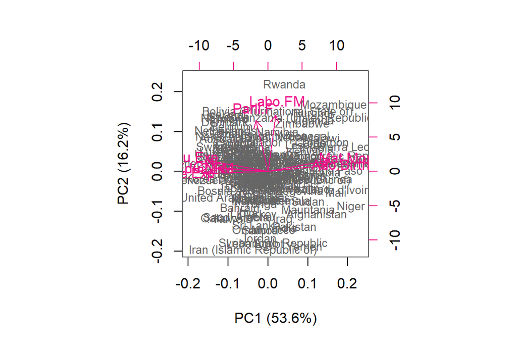

```r
# draw a biplot
biplot(pca_human, cex = c(0.8, 1), col = c("grey40", "deeppink2"), xlab = pc_lab[1], ylab = pc_lab[2])
```

In the biplot, the angle between the arrows can be interpreted as the correlation between the variables. We can see that for example the angle between Labo.FM and Abo.Birth is almost 90 degrees, which means that there is almost no correlation between the variables (Corr 0.12).

Since arrows of variables Mat.Mor and Ado.Birth are almost parallel, that shows that there is correlation between them. Similary, Life.Exp, GNI and Edu.Exp are also almost parallel so there is strong correlation between them. All of them are almost parralel with PC1 so they are part of this dimension. Similarly, Labo.FM and Parli.F belong to PC2 dimension.

## Personal interpretations

To me, the biplot clearly shows relationships between variables and how they group together.

If we look the dimension PC1 we can see two groups of variables. On the one side, we have strongly positivly correlated *Maternal mortality ratio* and *Adolescent birth rate* and on the other side there are (also between them strongly correlated): *Gross National Income per capita*, *Life expectancy at birth* and *Expected years of schooling*. Since these two gropus are on oposite sides of PC1, they are strongly negatively correlated.

On the other hand, the dimension PC2 shows positive correlation between *Percetange of female representatives in parliament* and *Ratio of proportion of females/males in the labour force*. This group is independant (not correlated) with the groups on PC1.

## Tea dataset

… didn’t have time to complete the chapter…

# Week 6 - Analysis of longitudinal data

This week we are working on analysis of two datasets: **BPRS** and **RATS**.

**BPRS** dataset contains psychiatric rating scale (BPRS) of 40 male subjects, divided in two treatement categories, that was measured before treatment (week 0) and during 8 week period. The measure is constructed of various psychiatric symptoms measured on scale from one (not present) to seven (extremely severe). The scale is used to evaluate patients suspected of having schizophrenia.

**RATS** dataset contains data from a study that meassured how rat’s body weight changes over time, being on a special diet. There were 3 different groups of rats, each one was on a different diet during a 9 week period.

This week is based on analysis examples from the Chapters 8 and 9 of [MABS](https://www.crcpress.com/Multivariate-Analysis-for-the-Behavioral-Sciences-Second-Edition/Vehkalahti-Everitt/p/book/9780815385158), which also has a [GitHub repository](https://github.com/KimmoVehkalahti/MABS).

## PART 1 - Chapter 8 analysis on RATS data

Both datasets were originally in a wide form, but in the data wrangling part we transformed it to a long form. Here we see long form of the RATS dataset, on which we will perform analysis.

```r
library(tidyr); library(dplyr); library(ggplot2)

RATSL <- read.table("D:/Senka/Work/IODS-project/data/ratsl.txt", header = T)
RATSL$ID <- factor(RATSL$ID)
RATSL$Group <- factor(RATSL$Group)
glimpse(RATSL)
```

```
## Observations: 176
## Variables: 5
## $ ID     <fct> 1, 2, 3, 4, 5, 6, 7, 8, 9, 10, 11, 12, 13, 14, 15, 16, ...
## $ Group  <fct> 1, 1, 1, 1, 1, 1, 1, 1, 2, 2, 2, 2, 3, 3, 3, 3, 1, 1, 1...
## $ WD     <fct> WD1, WD1, WD1, WD1, WD1, WD1, WD1, WD1, WD1, WD1, WD1, ...
## $ Weight <int> 240, 225, 245, 260, 255, 260, 275, 245, 410, 405, 445, ...
## $ Time   <int> 1, 1, 1, 1, 1, 1, 1, 1, 1, 1, 1, 1, 1, 1, 1, 1, 8, 8, 8...
```

```r
head(RATSL)
```

```
##   ID Group  WD Weight Time
## 1  1     1 WD1    240    1
## 2  2     1 WD1    225    1
## 3  3     1 WD1    245    1
## 4  4     1 WD1    260    1
## 5  5     1 WD1    255    1
## 6  6     1 WD1    260    1
```

```r
tail(RATSL)
```

```
##     ID Group   WD Weight Time
## 171 11     2 WD64    472   64
## 172 12     2 WD64    628   64
## 173 13     3 WD64    525   64
## 174 14     3 WD64    559   64
## 175 15     3 WD64    548   64
## 176 16     3 WD64    569   64
```

### Figure 1

This figure shows the data in graphical format. There are 3 groups of rats, divided by their diet. On the graphs wee see how their weight changed during the duration of the experiment.

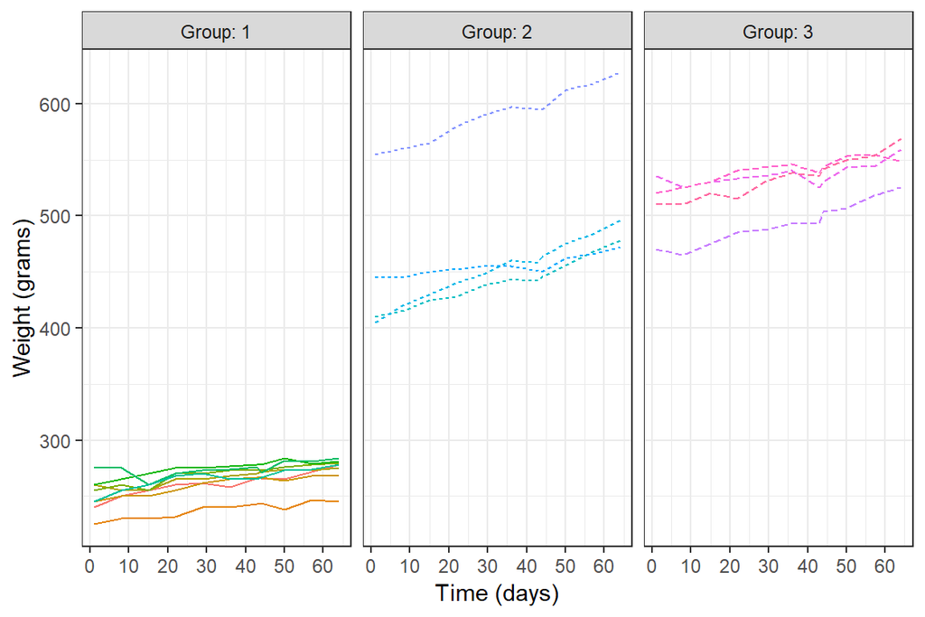

```r
p1 <- ggplot(RATSL, aes(x = Time, y = Weight,  col = ID))
p2 <- p1 + geom_line(aes(linetype = Group))
p3 <- p2 + scale_x_continuous(name = "Time (days)", breaks = seq(0, 60, 10))
p4 <- p3 + scale_y_continuous(name = "Weight (grams)")
p5 <- p4 + theme_bw() + theme(legend.position = "none")
p6 <- p5 + facet_grid(. ~ Group, labeller = label_both)
p6
```

### Figure 2

Now we calculate standardized values of each observation in order to see the tracking phenomenon (rats who start with higher weight tend to have heigher weight throughout the study).

Standardization is done by subtracting the relevant occasion mean from the original observation and then dividing by the corresponding visit standard deviation.

```r
# Standardise the Weight
RATSL <- RATSL %>%
  group_by(WD) %>%
  mutate(sdweight = (Weight - mean(Weight))/sd(Weight) ) %>%
  ungroup()

glimpse(RATSL)
```

```
## Observations: 176
## Variables: 6
## $ ID       <fct> 1, 2, 3, 4, 5, 6, 7, 8, 9, 10, 11, 12, 13, 14, 15, 16...
## $ Group    <fct> 1, 1, 1, 1, 1, 1, 1, 1, 2, 2, 2, 2, 3, 3, 3, 3, 1, 1,...
## $ WD       <fct> WD1, WD1, WD1, WD1, WD1, WD1, WD1, WD1, WD1, WD1, WD1...
## $ Weight   <int> 240, 225, 245, 260, 255, 260, 275, 245, 410, 405, 445...
## $ Time     <int> 1, 1, 1, 1, 1, 1, 1, 1, 1, 1, 1, 1, 1, 1, 1, 1, 8, 8,...
## $ sdweight <dbl> -1.0011429, -1.1203857, -0.9613953, -0.8421525, -0.88...
```

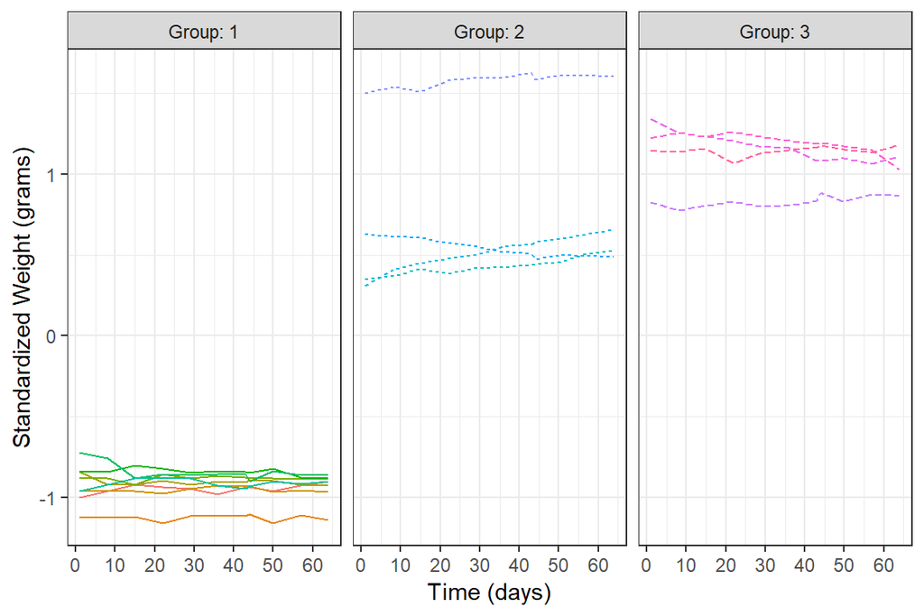

```r
p1 <- ggplot(RATSL, aes(x = Time, y = sdweight, col = ID))
p2 <- p1 + geom_line(aes(linetype = Group))
p3 <- p2 + scale_x_continuous(name = "Time (days)", breaks = seq(0, 60, 10))
p4 <- p3 + scale_y_continuous(name = "Standardized Weight (grams)")
p5 <- p4 + theme_bw() + theme(legend.position = "none")
p6 <- p5 + facet_grid(. ~ Group, labeller = label_both)
p6
```

### Figure 3

In order to better represent graphically large number of observations, it is useful to show the standard error of mean profiles for each group.

It seems that Group 2 had the highest weight gain over the time, while Group 1 had the slowest.

```r
# Number of weeks, baseline (week 0) included:
n <- RATSL$Time %>% unique() %>% length()
# Make a summary data:
RATSS <- RATSL %>%
  group_by(Group, Time) %>%
  summarise( mean=mean(Weight), se=sd(Weight)/sqrt(n) ) %>%
  ungroup()
glimpse(RATSS)
```

```
## Observations: 33
## Variables: 4
## $ Group <fct> 1, 1, 1, 1, 1, 1, 1, 1, 1, 1, 1, 2, 2, 2, 2, 2, 2, 2, 2,...
## $ Time  <int> 1, 8, 15, 22, 29, 36, 43, 44, 50, 57, 64, 1, 8, 15, 22, ...
## $ mean  <dbl> 250.625, 255.000, 254.375, 261.875, 264.625, 265.000, 26...
## $ se    <dbl> 4.589478, 3.947710, 3.460116, 4.100800, 3.333956, 3.5529...
```

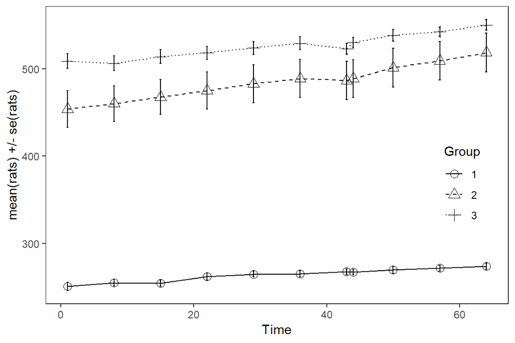

```r
p1 <- ggplot(RATSS, aes(x = Time, y = mean, linetype = Group, shape = Group))
p2 <- p1 + geom_line() + scale_linetype_manual(values = c(1,2,3))
p3 <- p2 + geom_point(size=3) + scale_shape_manual(values = c(1,2,3))
p4 <- p3 + geom_errorbar(aes(ymin=mean-se, ymax=mean+se, linetype="1"), width=0.3)
p5 <- p4 + theme_bw() + theme(panel.grid.major = element_blank(), panel.grid.minor = element_blank())
p6 <- p5 + theme(legend.position = c(0.9,0.4))
p7 <- p6 + scale_y_continuous(name = "mean(rats) +/- se(rats)")
p7
```

### Figure 4

Now we will check box plots, first for all measurments over the time. We can see that there are outliers in almost every measurment.

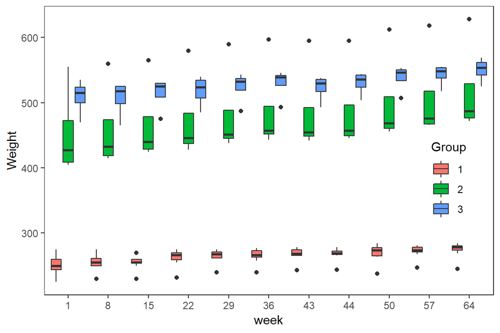

```r
p1 <- ggplot(RATSL, aes(x = factor(Time), y = Weight, fill = Group))
p2 <- p1 + geom_boxplot(position = position_dodge(width = 0.9))
p3 <- p2 + theme_bw() + theme(panel.grid.major = element_blank(), panel.grid.minor = element_blank())
p4 <- p3 + theme(legend.position = c(0.9,0.4))
p5 <- p4 + scale_x_discrete(name = "week")
# Black & White version:
#p6 <- p5 + scale_fill_grey(start = 0.5, end = 1)
p5
```

### Figure 5

In order to better understand changes between the groups, we will summarize measurments for each group over the period of time. However, we see that there is one outlier in each group that could bias the conclusions from further comparisons of the groups.

```r
# Make a summary data of the post treatment weeks (1-8)
RATSL8S <- RATSL %>%
  filter(Time > 0) %>%
  group_by(Group, ID) %>%
  summarise( mean=mean(Weight) ) %>%
  ungroup()
glimpse(RATSL8S)
```

```
## Observations: 16
## Variables: 3
## $ Group <fct> 1, 1, 1, 1, 1, 1, 1, 1, 2, 2, 2, 2, 3, 3, 3, 3
## $ ID    <fct> 1, 2, 3, 4, 5, 6, 7, 8, 9, 10, 11, 12, 13, 14, 15, 16
## $ mean  <dbl> 261.0909, 237.6364, 260.1818, 266.5455, 269.4545, 274.72...
```

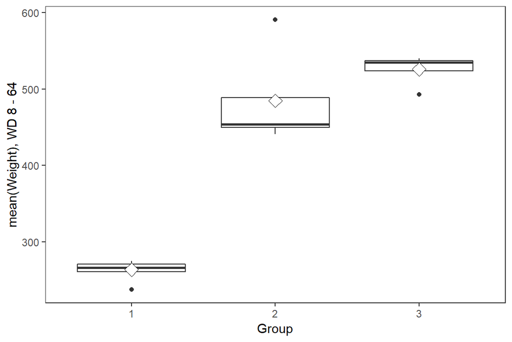

```r
p1 <- ggplot(RATSL8S, aes(x = Group, y = mean))
p2 <- p1 + geom_boxplot()
p3 <- p2 + theme_bw() + theme(panel.grid.major = element_blank(), panel.grid.minor = element_blank())
p4 <- p3 + stat_summary(fun.y = "mean", geom = "point", shape=23, size=4, fill = "white")
p5 <- p4 + scale_y_continuous(name = "mean(Weight), WD 8 - 64")
p5
```

### Figure 6

```r
# Remove the outlier:
RATSL8S1 <- RATSL8S %>%
  filter((Group == 1 & mean > 250) | (Group == 2 & mean < 560) | (Group == 3 & mean > 520))
glimpse(RATSL8S1)
```

```
## Observations: 13
## Variables: 3
## $ Group <fct> 1, 1, 1, 1, 1, 1, 1, 2, 2, 2, 3, 3, 3
## $ ID    <fct> 1, 3, 4, 5, 6, 7, 8, 9, 10, 11, 14, 15, 16
## $ mean  <dbl> 261.0909, 260.1818, 266.5455, 269.4545, 274.7273, 274.63...
```

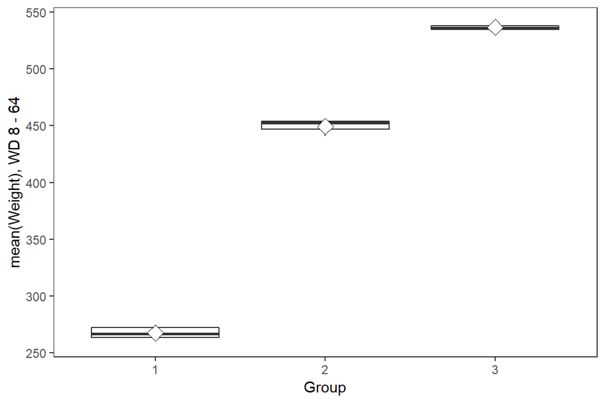

```r
p1 <- ggplot(RATSL8S1, aes(x = Group, y = mean))
p2 <- p1 + geom_boxplot()
p3 <- p2 + theme_bw() + theme(panel.grid.major = element_blank(), panel.grid.minor = element_blank())
p4 <- p3 + stat_summary(fun.y = "mean", geom = "point", shape=23, size=4, fill = "white")
p5 <- p4 + scale_y_continuous(name = "mean(Weight), WD 8 - 64")
p5
```

### Table 1

Can’t do the t-test because there are 3 group means (t-test is ok only when there are 2 group means).

### Table 2

Now we add the baseline from the original data as a new variable to the summary data and fit the linear model with the mean as the response.

```r
# Add the baseline from the original data as a new variable to the summary data:
RATS <- read.table("https://raw.githubusercontent.com/KimmoVehkalahti/MABS/master/Examples/data/rats.txt", header = T)
baseline <- RATS$WD1
RATSL8S2 <- RATSL8S %>% mutate(baseline)
# Fit the ANCOVA model and see the results:
fit <- lm(mean ~ baseline + Group, data = RATSL8S2)
summary(fit)
```

```
##
## Call:
## lm(formula = mean ~ baseline + Group, data = RATSL8S2)
##
## Residuals:
##     Min      1Q  Median      3Q     Max
## -21.732  -3.812   1.991   6.889  13.455
##
## Coefficients:
##             Estimate Std. Error t value Pr(>|t|)
## (Intercept) 30.14886   19.88779   1.516   0.1554
## baseline     0.93194    0.07793  11.959 5.02e-08 ***
## Group2      31.68866   17.11189   1.852   0.0888 .
## Group3      21.52296   21.13931   1.018   0.3287
## ---
## Signif. codes:  0 '***' 0.001 '**' 0.01 '*' 0.05 '.' 0.1 ' ' 1
##
## Residual standard error: 10.62 on 12 degrees of freedom
## Multiple R-squared:  0.9947, Adjusted R-squared:  0.9933
## F-statistic: 747.8 on 3 and 12 DF,  p-value: 6.636e-14
```

```r
anova(fit)
```

```
## Analysis of Variance Table
##
## Response: mean
##           Df Sum Sq Mean Sq   F value    Pr(>F)
## baseline   1 252125  252125 2237.0655 5.217e-15 ***
## Group      2    726     363    3.2219   0.07586 .
## Residuals 12   1352     113
## ---
## Signif. codes:  0 '***' 0.001 '**' 0.01 '*' 0.05 '.' 0.1 ' ' 1
```

We can see that the baseline weight is strongly related to the weight taken in the end of the study.

## PART 2 - Chapter 9 analysis on BPRS data

### Table 1

Here is the wide format of the BPRS data.

```r
BPRS <- read.table("https://raw.githubusercontent.com/KimmoVehkalahti/MABS/master/Examples/data/BPRS.txt", sep  =" ", header = T)
BPRS$treatment <- factor(BPRS$treatment)
BPRS$subject <- factor(BPRS$subject)
glimpse(BPRS)
```

```
## Observations: 40
## Variables: 11
## $ treatment <fct> 1, 1, 1, 1, 1, 1, 1, 1, 1, 1, 1, 1, 1, 1, 1, 1, 1, 1...
## $ subject   <fct> 1, 2, 3, 4, 5, 6, 7, 8, 9, 10, 11, 12, 13, 14, 15, 1...
## $ week0     <int> 42, 58, 54, 55, 72, 48, 71, 30, 41, 57, 30, 55, 36, ...
## $ week1     <int> 36, 68, 55, 77, 75, 43, 61, 36, 43, 51, 34, 52, 32, ...
## $ week2     <int> 36, 61, 41, 49, 72, 41, 47, 38, 39, 51, 34, 49, 36, ...
## $ week3     <int> 43, 55, 38, 54, 65, 38, 30, 38, 35, 55, 41, 54, 31, ...
## $ week4     <int> 41, 43, 43, 56, 50, 36, 27, 31, 28, 53, 36, 48, 25, ...
## $ week5     <int> 40, 34, 28, 50, 39, 29, 40, 26, 22, 43, 36, 43, 25, ...
## $ week6     <int> 38, 28, 29, 47, 32, 33, 30, 26, 20, 43, 38, 37, 21, ...
## $ week7     <int> 47, 28, 25, 42, 38, 27, 31, 25, 23, 39, 36, 36, 19, ...
## $ week8     <int> 51, 28, 24, 46, 32, 25, 31, 24, 21, 32, 36, 31, 22, ...
```

### Table 2

Now we convert it into the long format that will be easier to analyse.

```r
# Convert to long form
BPRSL <-  BPRS %>% gather(key = weeks, value = bprs, -treatment, -subject)
# Extract the week number
BPRSL <-  BPRSL %>% mutate(week = as.integer(substr(BPRSL$weeks, 5,6)))
glimpse(BPRSL)
```

```
## Observations: 360
## Variables: 5
## $ treatment <fct> 1, 1, 1, 1, 1, 1, 1, 1, 1, 1, 1, 1, 1, 1, 1, 1, 1, 1...
## $ subject   <fct> 1, 2, 3, 4, 5, 6, 7, 8, 9, 10, 11, 12, 13, 14, 15, 1...
## $ weeks     <chr> "week0", "week0", "week0", "week0", "week0", "week0"...
## $ bprs      <int> 42, 58, 54, 55, 72, 48, 71, 30, 41, 57, 30, 55, 36, ...
## $ week      <int> 0, 0, 0, 0, 0, 0, 0, 0, 0, 0, 0, 0, 0, 0, 0, 0, 0, 0...
```

```r
head(BPRSL); tail(BPRSL)
```

```
##   treatment subject weeks bprs week
## 1         1       1 week0   42    0
## 2         1       2 week0   58    0
## 3         1       3 week0   54    0
## 4         1       4 week0   55    0
## 5         1       5 week0   72    0
## 6         1       6 week0   48    0
```

```
##     treatment subject weeks bprs week
## 355         2      15 week8   37    8
## 356         2      16 week8   22    8
## 357         2      17 week8   43    8
## 358         2      18 week8   30    8
## 359         2      19 week8   21    8
## 360         2      20 week8   23    8
```

### Figure 1

This graph shows how the BPRS measures change over time for each treatement category. I guess this isn’t the best graph for this data, it is really hard to notice anything useful.

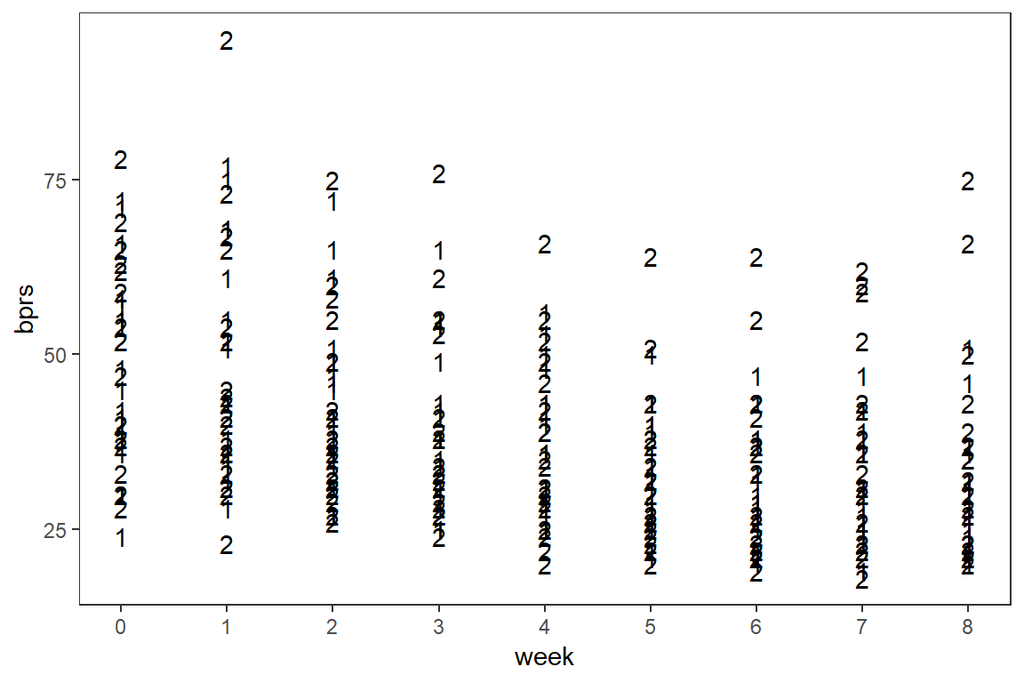

```r
p1 <- ggplot(BPRSL, aes(x = week, y = bprs, group = subject))
p2 <- p1 + geom_text(aes(label = treatment))
p3 <- p2 + scale_x_continuous(name = "week", breaks = seq(0, 8, 1))
p4 <- p3 + scale_y_continuous(name = "bprs")
p5 <- p4 + theme_bw()
p6 <- p5 + theme(panel.grid.major = element_blank(), panel.grid.minor = element_blank())
p6
```

### Table 3

Here we try to fit a multiple linear regression model with bprs as response and week and treatment as explanatory variables. This is not a good model for this dataset, because it assumes independance of the repeated measres of BPRS, which is not the case.

```r
BPRS_reg <- lm(bprs ~ week + treatment, data = BPRSL)
summary(BPRS_reg)
```

```
##
## Call:
## lm(formula = bprs ~ week + treatment, data = BPRSL)
##
## Residuals:
##     Min      1Q  Median      3Q     Max
## -22.454  -8.965  -3.196   7.002  50.244
##
## Coefficients:
##             Estimate Std. Error t value Pr(>|t|)
## (Intercept)  46.4539     1.3670  33.982   <2e-16 ***
## week         -2.2704     0.2524  -8.995   <2e-16 ***
## treatment2    0.5722     1.3034   0.439    0.661
## ---
## Signif. codes:  0 '***' 0.001 '**' 0.01 '*' 0.05 '.' 0.1 ' ' 1
##
## Residual standard error: 12.37 on 357 degrees of freedom
## Multiple R-squared:  0.1851, Adjusted R-squared:  0.1806
## F-statistic: 40.55 on 2 and 357 DF,  p-value: < 2.2e-16
```

### Figure 2

Now we plot graphs that visully better represent the data. There are 2 treatement groups and wee can see how the individual measures of BPRS change over time.

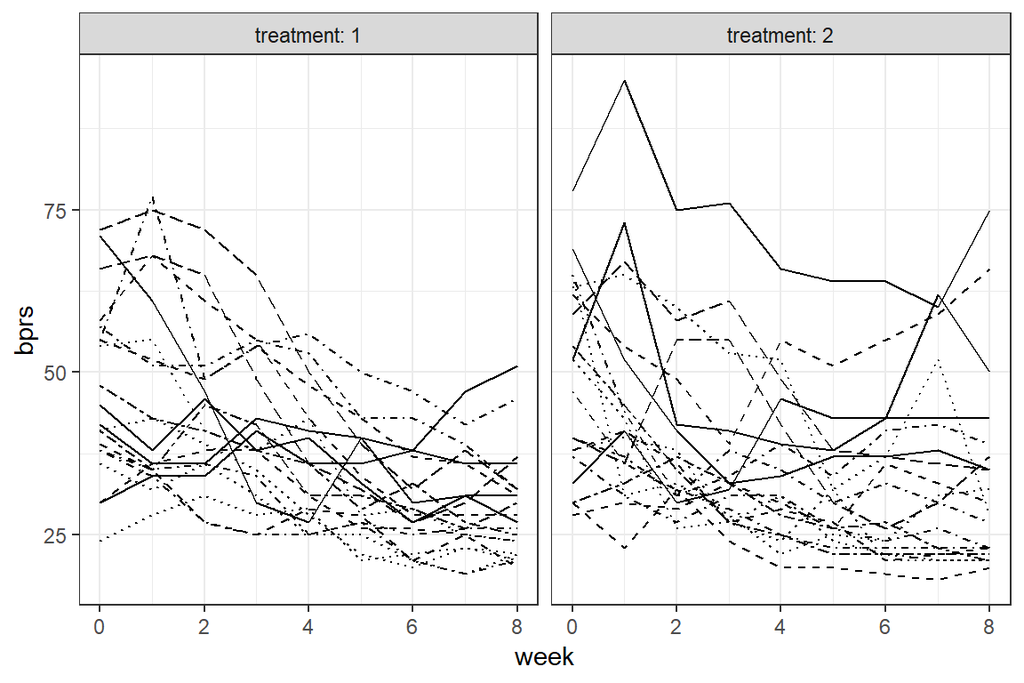

```r
p1 <- ggplot(BPRSL, aes(x = week, y = bprs, linetype = subject))
p2 <- p1 + geom_line()
p3 <- p2 + scale_linetype_manual(values = rep(1:10, times=4))
p4 <- p3 + facet_grid(. ~ treatment, labeller = label_both)
p5 <- p4 + theme_bw() + theme(legend.position = "none")
p6 <- p5 + scale_y_continuous(limits = c(min(BPRSL$bprs), max(BPRSL$bprs)))
p6
```

### Figure 3

Pairs graph clearly shows clustering of the data based on treatement. There are also noticable outliers in many week/treatement pairs (upper right corners).

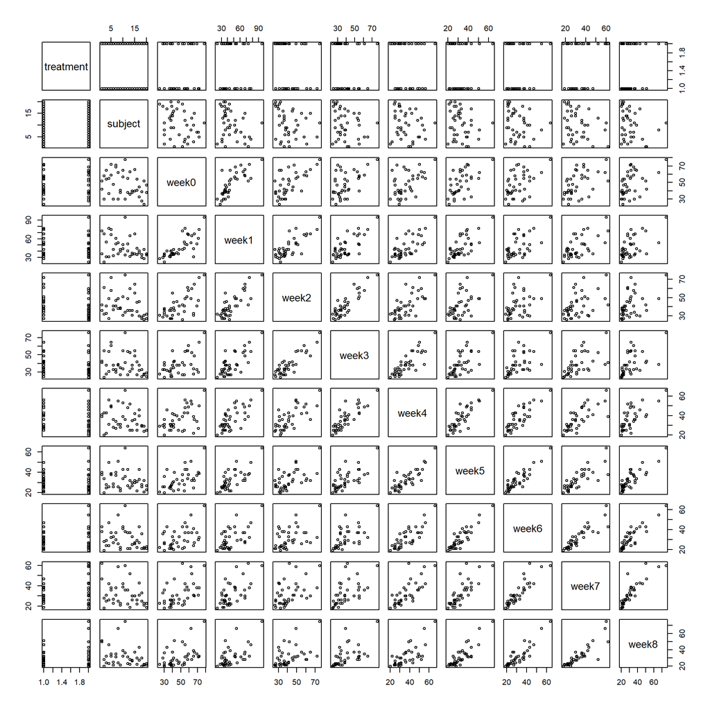

```r
pairs(BPRS, cex = 0.7)
```

### Table 4

Random intercept model would suit this dataset better than the lm.

```r
# install.packages("lme4")
library("lme4")
BPRS_ref <- lmer(bprs ~ week + treatment + (1 | subject), data = BPRSL, REML = FALSE)
summary(BPRS_ref)
```

```
## Linear mixed model fit by maximum likelihood  ['lmerMod']
## Formula: bprs ~ week + treatment + (1 | subject)
##    Data: BPRSL
##
##      AIC      BIC   logLik deviance df.resid
##   2748.7   2768.1  -1369.4   2738.7      355
##
## Scaled residuals:
##     Min      1Q  Median      3Q     Max
## -3.0481 -0.6749 -0.1361  0.4813  3.4855
##
## Random effects:
##  Groups   Name        Variance Std.Dev.
##  subject  (Intercept)  47.41    6.885
##  Residual             104.21   10.208
## Number of obs: 360, groups:  subject, 20
##
## Fixed effects:
##             Estimate Std. Error t value
## (Intercept)  46.4539     1.9090  24.334
## week         -2.2704     0.2084 -10.896
## treatment2    0.5722     1.0761   0.532
##
## Correlation of Fixed Effects:
##            (Intr) week
## week       -0.437
## treatment2 -0.282  0.000
```

```r
# dummies (in Table) vs summary output: D1 = treatment2, D2 = treatment3
```

### Table 5

```r
BPRS_ref1 <- lmer(bprs ~ week + treatment + (week | subject), data = BPRSL, REML = FALSE)
summary(BPRS_ref1)
```

```
## Linear mixed model fit by maximum likelihood  ['lmerMod']
## Formula: bprs ~ week + treatment + (week | subject)
##    Data: BPRSL
##
##      AIC      BIC   logLik deviance df.resid
##   2745.4   2772.6  -1365.7   2731.4      353
##
## Scaled residuals:
##     Min      1Q  Median      3Q     Max
## -2.8919 -0.6194 -0.0691  0.5531  3.7976
##
## Random effects:
##  Groups   Name        Variance Std.Dev. Corr
##  subject  (Intercept) 64.8202  8.0511
##           week         0.9608  0.9802   -0.51
##  Residual             97.4307  9.8707
## Number of obs: 360, groups:  subject, 20
##
## Fixed effects:
##             Estimate Std. Error t value
## (Intercept)  46.4539     2.1052  22.066
## week         -2.2704     0.2977  -7.626
## treatment2    0.5722     1.0405   0.550
##
## Correlation of Fixed Effects:
##            (Intr) week
## week       -0.582
## treatment2 -0.247  0.000
```

```r
# dummies (in Table) vs summary output: D1 = Group2, D2 = Group3
anova(BPRS_ref1, BPRS_ref)
```

```
## Data: BPRSL
## Models:
## BPRS_ref: bprs ~ week + treatment + (1 | subject)
## BPRS_ref1: bprs ~ week + treatment + (week | subject)
##           Df    AIC    BIC  logLik deviance  Chisq Chi Df Pr(>Chisq)
## BPRS_ref   5 2748.7 2768.1 -1369.4   2738.7
## BPRS_ref1  7 2745.4 2772.6 -1365.7   2731.4 7.2721      2    0.02636 *
## ---
## Signif. codes:  0 '***' 0.001 '**' 0.01 '*' 0.05 '.' 0.1 ' ' 1
```

### Table 6

```r
BPRS_ref2 <- lmer(bprs ~ week * treatment + (week | subject), data = BPRSL, REML = FALSE)
summary(BPRS_ref2)
```

```
## Linear mixed model fit by maximum likelihood  ['lmerMod']
## Formula: bprs ~ week * treatment + (week | subject)
##    Data: BPRSL
##
##      AIC      BIC   logLik deviance df.resid
##   2744.3   2775.4  -1364.1   2728.3      352
##
## Scaled residuals:
##     Min      1Q  Median      3Q     Max
## -3.0512 -0.6271 -0.0767  0.5288  3.9260
##
## Random effects:
##  Groups   Name        Variance Std.Dev. Corr
##  subject  (Intercept) 65.0016  8.0624
##           week         0.9688  0.9843   -0.51
##  Residual             96.4699  9.8219
## Number of obs: 360, groups:  subject, 20
##
## Fixed effects:
##                 Estimate Std. Error t value
## (Intercept)      47.8856     2.2522  21.262
## week             -2.6283     0.3589  -7.323
## treatment2       -2.2911     1.9090  -1.200
## week:treatment2   0.7158     0.4010   1.785
##
## Correlation of Fixed Effects:
##             (Intr) week   trtmn2
## week        -0.650
## treatment2  -0.424  0.469
## wek:trtmnt2  0.356 -0.559 -0.840
```

```r
# dummies (in Table) vs summary output: D1 = Group2, D2 = Group3
anova(BPRS_ref1, BPRS_ref2)
```

```
## Data: BPRSL
## Models:
## BPRS_ref1: bprs ~ week + treatment + (week | subject)
## BPRS_ref2: bprs ~ week * treatment + (week | subject)
##           Df    AIC    BIC  logLik deviance  Chisq Chi Df Pr(>Chisq)
## BPRS_ref1  7 2745.4 2772.6 -1365.7   2731.4
## BPRS_ref2  8 2744.3 2775.4 -1364.1   2728.3 3.1712      1    0.07495 .
## ---
## Signif. codes:  0 '***' 0.001 '**' 0.01 '*' 0.05 '.' 0.1 ' ' 1
```

### Figure 4

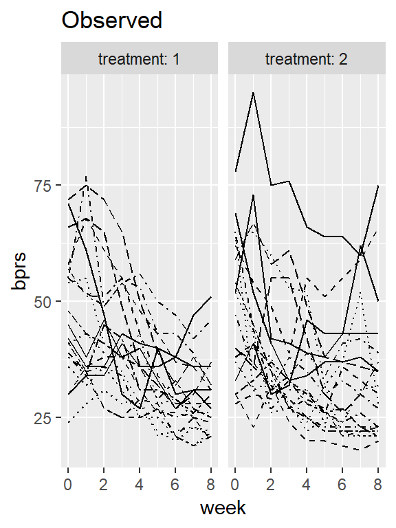

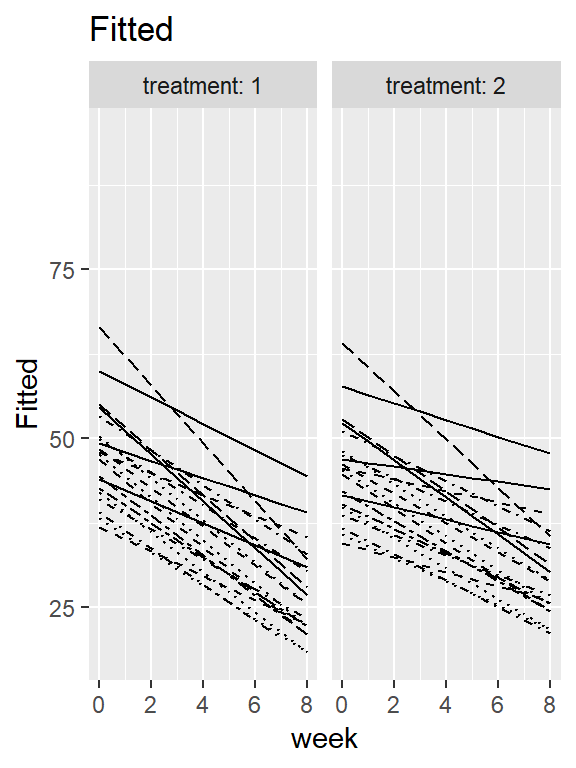

```r
Fitted <- fitted(BPRS_ref2)
BPRSL <- BPRSL %>% mutate(Fitted)

p1 <- ggplot(BPRSL, aes(x = week, y = bprs, linetype = subject))
p2 <- p1 + geom_line()
p3 <- p2 + scale_linetype_manual(values = rep(1:10, times=4))
p4 <- p3 + facet_grid(. ~ treatment, labeller = label_both)
p5 <- p4 + theme(legend.position = "none")
p6 <- p5 + scale_y_continuous(limits = c(min(BPRSL$bprs), max(BPRSL$bprs)))
p7 <- p6 + ggtitle("Observed")
graph1 <- p7

p1 <- ggplot(BPRSL, aes(x = week, y = Fitted, linetype = subject))
p2 <- p1 + geom_line()
p3 <- p2 + scale_linetype_manual(values = rep(1:10, times=4))
p4 <- p3 + facet_grid(. ~ treatment, labeller = label_both)
p5 <- p4 + theme(legend.position = "none")
p6 <- p5 + scale_y_continuous(limits = c(min(BPRSL$bprs), max(BPRSL$bprs)))
p7 <- p6 + ggtitle("Fitted")
graph2 <- p7



graph1; graph2
```